# NC Genes ATAC-Seq Signal

## Running Annotation on diffbind

```r
TxDb_galGal6 <- makeTxDbFromEnsembl(organism = "Gallus gallus", release = 101)
```

```
Fetch transcripts and genes from Ensembl ... OK
Fetch exons and CDS from Ensembl ... OK
Fetch chromosome names and lengths from Ensembl ...OK
Gather the metadata ... OK
Make the TxDb object ... OK
```

## Importing diffTF results

I used (with great difficulty) the program diffTF to perform integration of our ATAC-Seq and RNA-Seq data. This program scans peaks for TFBS’s, and then associates the accessibility of those sites in aggregate to the RNA-Seq expression levels of eligible genes. Thus, it is able to classify each transcription factor as an activator, repressor, or undetermined. Undetermined genes may have both activities, or no real specific activity.

```r
saveRDS(impulse_obj2, file = "Exports/ATAC-Seq-Impulse.RDS")
saveRDS(impulse_obj2, file = "Exports/ATAC-Seq-Impulse.RDS")
lsgplotsGenes2 <- plotGenes(
  vecGeneIDs       = NULL,
  scaNTopIDs       = 10,
  objectImpulseDE2 = impulse_obj2,
  boolCaseCtrl     = F,
  boolSimplePlot   = T,
  dirOut           = NULL,
  strFileName      = NULL,
  vecRefPval       = NULL,
  strNameRefMethod = NULL)
```

```
[1] "Setting boolSimplePlot=TRUE as no batch structure was found."
```

```r
lsgplotsGenes2 <- plotGenes(
  vecGeneIDs       = NULL,
  scaNTopIDs       = 10,
  objectImpulseDE2 = impulse_obj2,
  boolCaseCtrl     = F,
  boolSimplePlot   = T,
  dirOut           = NULL,
  strFileName      = NULL,
  vecRefPval       = NULL,
  strNameRefMethod = NULL)
```

```
[1] "Setting boolSimplePlot=TRUE as no batch structure was found."
```

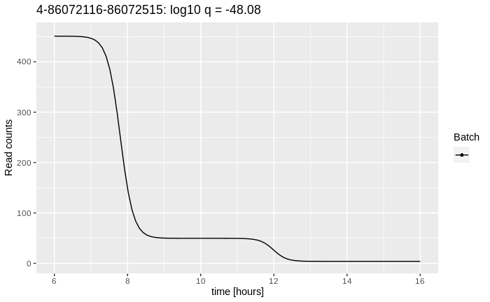

```r
lsgplotsGenes2[[1]]
```

1. Retrieve gene impulse model
2. For every peak for that gene, find the correlation
3. Get a set of random peaks that are not for that gene and find the average correlation for unrelated peaks. Did this, it is 0!
4. Report, maybe determine some sort of cutoff?

```r
# So one way is to increase the annotation of our ATAC_all_peaks_anno.
# We want to bump it out to the 5 nearest genes.
# Currently our function looks for peakIDs that are annotated by a certain gene.
# We should look for the nearest 5 genes for each peak and add each as a new row.
# We can use bedtools closest to accomplish this.
TxDb_galGal6 <- makeTxDbFromEnsembl(organism = "Gallus gallus", release = 101)
genes <- promoters(genes(TxDb_galGal6),
          upstream=1500, downstream=500)
genes <- trim(genes)

export.bed(object = genes, con = "Exports/ENSEMBL_101_TSS.bed")

# Now annotate the peaks with the nearest 5 genes.
```

```r
awk '{ if ($2 > 0) { print } }' ./Exports/ENSEMBL_101_TSS.bed > ./Exports/ENSEMBL_101_TSS_filt.bed
bedtools sort -i ./Exports/ENSEMBL_101_TSS_filt.bed > ./Exports/ENSEMBL_101_TSS_sort.bed

bedtools closest -k 5 -D b -b ./Exports/ENSEMBL_101_TSS_sort.bed -a ./Exports/ATAC_Filtered_Peaks.bed > ./Exports/ATAC_Filtered_Peaks_Closest_5_genes.bed
```

```r
source(file = "Peak-Gene-Fitting_2.R")
register(BPPARAM = MulticoreParam(progressbar = T, workers = 12, stop.on.error = F))
impulse_obj <- readRDS("../RNA-Seq/Exports/impulse_obj.RDS")
impulse_obj_ATAC <- readRDS("Exports/ATAC-Seq-Impulse.RDS")
ATAC_all_peaks_anno.df <- readRDS("Exports/ATAC_all_peaks_anno.RDS")
closest_5_genes <- read.delim("Exports/ATAC_Filtered_Peaks_Closest_5_genes.bed", sep ="\t", header = F)
colnames(closest_5_genes) <- c("peakChr","peakStart",
                               "peakStop","peakStrand",
                               "peakWidth","peakScore",
                               "tssChr","tssStart","tssStop",
                               "geneId","geneScore",
                               "GeneStrand","distanceToTSS")
# Shift start +1 bp to match ATAC obj.
closest_5_genes$peakStart <- closest_5_genes$peakStart + 1

closest_5_genes$PeakID <- paste0(closest_5_genes$peakChr,
                                 "-",closest_5_genes$peakStart,"-",
                                 closest_5_genes$peakStop)
closest_5_genes$geneId <- as.character(closest_5_genes$geneId)
GRN_Genes <- read.csv(file = "./Imports/GRN_Genes.csv", header = F)
colnames(GRN_Genes) <- c("Symbol","ENSEMBL")
GenesUniverse <- read_csv("../RNA-Seq/Imports/GenesUniverse.csv")
TC_NC_Enriched <- read_csv("../RNA-Seq/Exports/ddsTC_Condition_WE_vc_NC_Enriched.csv")
TC_NC_Enriched_TF <- subset(TC_NC_Enriched, TC_NC_Enriched$TF_Status == "Transcription Factor")

#Window25bp.gr <- readRDS(file = "Imports/Phastcons_77vert_25bpWindows.gr.RDS")
# GRN_enhancers <- RunMultipleGenes(genelist = as.character(GRN_Genes$ENSEMBL))
```

## Comparison of DiffTF activator/repressor call to trrust database.

```r
library(readr)
library(qdapTools)
output_global_TFs <- read_csv("Imports/output.global.TFs.csv")
output_global_TFs_orig <- read_csv("Imports/output.global.TFs.orig.csv")
all_timepoints_summary <- read_delim("Imports/all.timepoints.summary.tsv",
                                     "\t", escape_double = FALSE, trim_ws = TRUE)
trans_table <- read_delim(file = "Imports/translationTable_gg6.csv", delim = " ")
# https://www.grnpedia.org/trrust/
trrust_rawdata_human <- read_delim("Imports/trrust_rawdata.human.tsv",
                                   "\t", escape_double = FALSE, col_names = FALSE,
                                   trim_ws = TRUE)
ddsTC_Condition_WE_vc_NC_All <- read_csv("../RNA-Seq/Exports/ddsTC_Condition_WE_vc_NC_All.csv")
all_timepoints_summary$Symbol <- lookup(all_timepoints_summary$TF, as.data.frame(trans_table[,c(3,1)]))
output_global_TFs$Symbol <- lookup(output_global_TFs$TF, as.data.frame(trans_table[,c(3,1)]))
output_global_TFs_orig$Symbol <- lookup(output_global_TFs_orig$TF, as.data.frame(trans_table[,c(3,1)]))

summary(as.factor(all_timepoints_summary$classification_q0.05_final))
```

```
    activator not-expressed     repressor  undetermined
          116           252           119           244
```

## Neural Crest TF Enhancers

```r
TC_NC_Enriched_TF_enhancers <- subset(All_Genes_Tests, All_Genes_Tests$gene %in% TC_NC_Enriched$Chick_ENSEMBL)
TC_NC_Enriched_TF_enhancers <- TC_NC_Enriched_TF_enhancers[!duplicated(TC_NC_Enriched_TF_enhancers$PeakID),]

TC_NC_Enriched_TF_enhancers <- TC_NC_Enriched_TF_enhancers %>% arrange(-spearman)
TC_NC_Enriched_TF_enhancers$rank <- seq(length(TC_NC_Enriched_TF_enhancers$PeakID))

# Let's plot

TC_NC_Enriched_TF_enhancers %>% ggplot(aes(x= rank, y=spearman)) +
  geom_rect(inherit.aes = F, aes(xmin = 1, xmax= 661, ymin=0.8, ymax = 1)) +
  geom_rect(inherit.aes = F,aes(xmin = 662, xmax= 1012, ymin=0.6, ymax = 0.8)) +
  geom_rect(inherit.aes = F,aes(xmin = 2579, xmax= 2899, ymin=-0.6, ymax = -0.8)) +
  geom_rect(inherit.aes = F,aes(xmin = 2900, xmax= max(rank), ymin= -0.8, ymax = -1)) +
  geom_point(col="#0A98B4", size=1) +   # Draw points
  labs(title = "Peak-Gene Correlation", y = "Spearman Correlation", x = "Ranked Peaks") +
  theme(axis.text.x = element_blank(),
        axis.ticks.x = element_blank(),
        panel.background = element_rect(color = "gray40")) +
  scale_y_continuous(breaks=seq(-1,1,0.2))

ggsave(filename = "Exports/Enhancer-Gene-Correlation_ddsTC_Enriched_TFs.eps",
       width = 8, height = 6)

# Strong+ (661), Moderate+ (351), Moderate- (321), Strong- (462)
TC_NC_Enriched_TF_enhancers.gr <- Signac::StringToGRanges(TC_NC_Enriched_TF_enhancers$PeakID)
TC_NC_Enriched_TF_enhancers.gr
TC_NC_Enriched_TF_enhancers_anno <- annotatePeak(TC_NC_Enriched_TF_enhancers.gr, tssRegion = c(-1000,1000), TxDb = TxDb_galGal6, annoDb = "org.Gg.eg.db", assignGenomicAnnotation = T)

TC_NC_Enriched_TF_enhancers_anno_df <- as.data.frame(TC_NC_Enriched_TF_enhancers_anno)
TC_NC_Enriched_TF_enhancers_anno_df$PeakID <- paste0(TC_NC_Enriched_TF_enhancers_anno_df$seqnames,"-",TC_NC_Enriched_TF_enhancers_anno_df$start,"-",TC_NC_Enriched_TF_enhancers_anno_df$end)

TC_NC_Enriched_TF_enhancers_anno_df <- TC_NC_Enriched_TF_enhancers_anno_df %>% mutate(spearman = lookup(PeakID, TC_NC_Enriched_TF_enhancers[,c("PeakID","spearman")]))

write_delim(TC_NC_Enriched_TF_enhancers_anno_df, path = "Exports/TC_NC_Enriched_TF_Enhancers_Annotated.txt", delim = "\t", col_names = T)
```

[output not shown]

# Incorporation of H3K27Ac Data

Investigate H3K27Ac at highly correlated vs lowly correlated in Neural-crest enriched genes. Is there evidence of greater chromatin activation in highly positively correlated elements?

```r
corr_summ_exp <- dba(H3K27Ac_corr, bSummarizedExperiment = T)
corr_summ_exp@assays@data$scores <- corr_summ_exp@assays@data$Reads
dds_corr <- DESeqDataSet(corr_summ_exp, design = ~ Tissue)
```

```
renaming the first element in assays to 'counts'
some variables in design formula are characters, converting to factors
```

```r
dds_corr <- DESeq(dds_corr)
dds_results <- results(dds_corr)
rld <- rlog(dds_corr, blind = T)
rld_df <- data.frame(row.names = paste0(H3K27Ac_corr$peaks[[1]]$Chr,"-",H3K27Ac_corr$peaks[[1]]$Start,"-",H3K27Ac_corr$peaks[[1]]$End),
           assay(rld))
search <- strong_correlates[,c("PeakID","spearman")]
search <- search[!duplicated(search$PeakID),]


Corr_group <- data.frame(
  PeakID = rownames(rld_df),
  spearman = qdapTools::lookup(terms = rownames(rld_df), key.match = search))
Corr_group$group <- as.factor(ifelse(Corr_group$spearman > 0.8, "Positive", ifelse(Corr_group$spearman < -0.8, "Negative", "None")))

Corr_group$group <- factor(Corr_group$group, levels = levels(Corr_group$group)[c(3,2,1)])

rld_df$Corr_group <- factor(qdapTools::lookup(rownames(rld_df), Corr_group[,c("PeakID","group")]),
                            levels = levels(as.factor(qdapTools::lookup(rownames(rld_df), Corr_group[,c("PeakID","group")])))[c(3,2,1)])

rld_df$PeakID <- rownames(rld_df)
rld_df_melt <- reshape2::melt(rld_df)
my_comparisons <- list( c("Negative", "None"), c("None", "Positive"), c("Positive", "Negative"))

ggplot(rld_df_melt, mapping = aes(x = Corr_group, y = value, color = Corr_group, group = Corr_group)) + geom_boxplot() + stat_compare_means(method = "t.test",comparisons = my_comparisons)

ggsave(filename = "Exports/Positive_vs_Negative_vs_None_strong_correlation_H3K27Ac_Levels.eps", width = 5, height = 7)
```

[output not shown]

```r
ggsave(filename = "Exports/NC_GRN_Enhancers_vs_random_Accessibility_over_time.pdf")
```